# DESCO - Knowledge Discovery - Forecast responses to future campaigns

1141074 - Sérgio Silva | 1970400 - Pedro Neves | 1040706 - Sérgio Castro

11/6/2018

Este documento é focado na parte do processo relativo à classificação de clientes, o objetivo é futuramente conseguirmos prever tendo em conta novos clientes, qual a reposta que se irá ter às campanhas.

Numa primeira fase vamos escolher que dados dos clientes vamos analisar e como analisar, bem como, algum tipo de tratamento que seja possível efetuar.

Para o calculo da métrica relativa ao RFM será necessário avaliar as tabelas **TRANSACTION.dat** e **TRANSACTION_ITEM.dat**

## Carregamento das tabelas de **TRANSACTION.dat** e **TRANSACTION_ITEM.dat**

#### Pré-processamento para fazer o merge das duas tabelas, definindo uma chave em ambas as tabelas para efetuar o merge.

```r
#Definir a key para efetuar o merge
keycols <- c('Store', 'Date', 'Time', 'TransactionID')

#Tabela TRANSACTION.dat
transactions = fread('DATA-CRM/TRANSACTION.dat')
setkeyv(transactions, keycols)

#Tabela TRANSACTION_ITEM.dat
trans_items = fread('DATA-CRM/TRANSACTION_ITEM.dat')
setkeyv(trans_items, keycols)
```

#### Efetuar ‘join’ das duas tabelas e remover as observacões contendo datas inválidas

```r
# Execução do merge
Result <- merge(transactions, trans_items, all = TRUE)

# Tratamento das datas para formato de data
Result[, Date := as.Date(as.character.Date(Date),"%Y%m%d")]

# verificar possíveis erros neste tratamento
Result <- na.omit(Result, cols = "Date")
```

#### Gerar RFM Score com package rfm

O modelo **RFM** (*Recency*, *Frequency*, *Monetary*) é um modelo muito usado para a categorização de clientes, por causa da sua simplicidade e boa capacidade de previsão.

Por defeito, o RFM atribui valores de 1 a 5 e apesar destes valores poderem ser configuráveis, consideramos que são suficientes para avaliar os dados dos clientes. As divisões feitas com 5 valores, dividem os valores a cada 20% dos dados. (Ref. Birant 2011)

Calculo do *Recency*, *Frequency*, *Monetary* a partir da tabela de transacões, resultado do *merge* anterior.

```r
# Data definida para a análise, foi escolhida a data de 01-01-2015 pois como os dados são
#de 2014, faria sentido aplicar esta análise nesta altura.
analysis_date <- as.Date("2015-01-01")


#Aplicação do package *rfm*, com os dados necessário de CardID, Data da última compra e Amount
orders <- Result[, .(CardID, Date, Amount)]
rfm_result <- rfm_table_order(data = orders, customer_id = CardID, order_date = Date, revenue = Amount, analysis_date = analysis_date, recency_bins = 5, frequency_bins = 5, monetary_bins = 5)
```

Análise dos dados obtidos na aplicação do algotirtmo de **RFM** do package *rfm*

```r
# Verificação visual dos dados
summary(rfm_result)
```

```
##    rfm.customer_id     rfm.date_most_recent    rfm.recency_days    rfm.transaction_count       rfm.amount        rfm.recency_score    rfm.frequency_score    rfm.monetary_score      rfm.rfm_score
##  Length:60519          Min.   :2014-01-01    Min.   :  2.0000      Min.   : 1.00000      Min.   :   1.490      Min.   :1.000000      Min.   :1.000000      Min.   :1.000000      Min.   :111.0000
##  Class :character      1st Qu.:2014-08-25    1st Qu.: 19.0000      1st Qu.: 2.00000      1st Qu.: 199.935      1st Qu.:2.000000      1st Qu.:1.000000      1st Qu.:2.000000      1st Qu.:214.0000
##  Mode  :character      Median :2014-11-06    Median : 56.0000      Median : 3.00000      Median : 338.980      Median :3.000000      Median :2.000000      Median :3.000000      Median :324.0000
##  NA                    Mean   :2014-10-07    Mean   : 85.7983      Mean   : 6.50012      Mean   : 426.210      Mean   :3.019911      Mean   :2.498736      Mean   :2.993225      Mean   :329.9717
##  NA                    3rd Qu.:2014-12-13    3rd Qu.:129.0000      3rd Qu.: 5.00000      3rd Qu.: 534.480      3rd Qu.:4.000000      3rd Qu.:4.000000      3rd Qu.:4.000000      3rd Qu.:453.0000
##  NA                    Max.   :2014-12-30    Max.   :365.0000      Max.   :95.00000      Max.   :6643.000      Max.   :5.000000      Max.   :5.000000      Max.   :5.000000      Max.   :555.0000
##  analysis_date        frequency_bins  recency_bins monetary_bins
##  Min.   :2015-01-01   Min.   :5      Min.   :5     Min.   :5
##  1st Qu.:2015-01-01   1st Qu.:5      1st Qu.:5     1st Qu.:5
##  Median :2015-01-01   Median :5      Median :5     Median :5
##  Mean   :2015-01-01   Mean   :5      Mean   :5     Mean   :5
##  3rd Qu.:2015-01-01   3rd Qu.:5      3rd Qu.:5     3rd Qu.:5
##  Max.   :2015-01-01   Max.   :5      Max.   :5     Max.   :5
```

```r
str(rfm_result)
```

```
## Classes 'rfm_table_order', 'tibble' and 'data.frame':    0 obs. of  5 variables:
##  $ rfm           :Classes 'tbl_df', 'tbl' and 'data.frame':  60519 obs. of  9 variables:
##   ..$ customer_id      : chr  "C0100000111" "C0100000199" "C0100000343" "C0100000375" ...
##   ..$ date_most_recent : Date, format: "2014-07-19" ...
##   ..$ recency_days     : num  166 3 116 61 13 3 82 45 22 271 ...
##   ..$ transaction_count: num  6 3 6 4 32 22 3 4 4 2 ...
##   ..$ amount           : num  883 597 701 224 626 ...
##   ..$ recency_score    : int  1 5 2 3 5 5 2 3 4 1 ...
##   ..$ frequency_score  : int  5 2 5 3 5 5 2 3 3 1 ...
##   ..$ monetary_score   : int  5 4 5 2 5 5 1 3 2 1 ...
##   ..$ rfm_score        : num  155 524 255 332 555 555 221 333 432 111 ...
##  $ analysis_date : Date, format: "2015-01-01"
##  $ frequency_bins: num 5
##  $ recency_bins  : num 5
##  $ monetary_bins : num 5
```

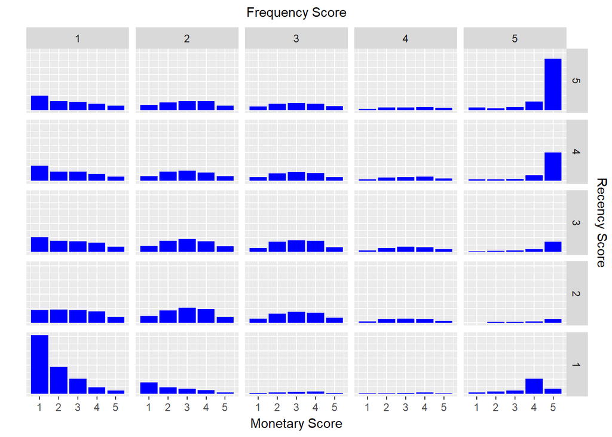

```r
# Examinar a distribuição dos resultados de monetary para diferentes combinações de resultados de frequency e recency.
rfm_bar_chart(rfm_result)
```

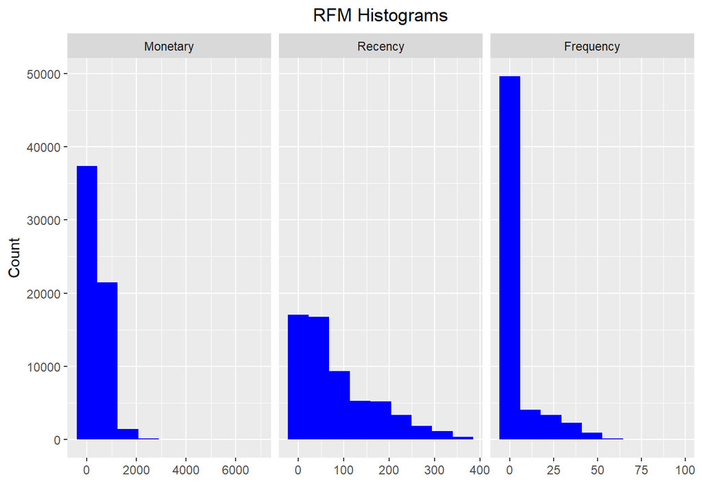

```r
# Distribuição dos Histogramas para as 3 medidas de Recency, Frequency e Monetary
rfm_histograms(rfm_result)
```